# Will the Real Hopkins Statistic Please Stand Up?

## Example 2: Randomly-spaced data

The `japanesepines` data contains the locations of 65 Japanese black pine saplings in a square 5.7 meters on a side. The plot of the data in Figure @ref(fig:japanesepines) is an example of data in which the events are randomly spaced.

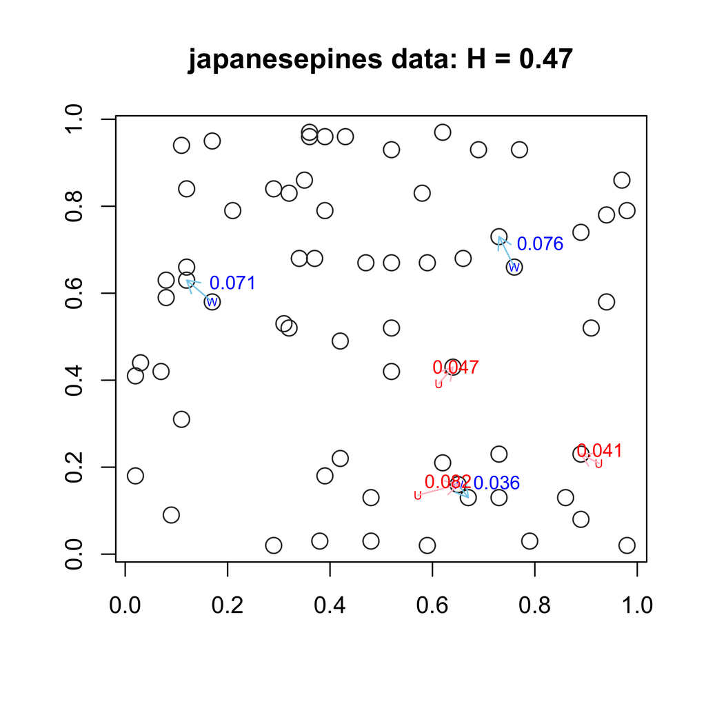

An example of how Hopkins statistic is calculated with randomly-spaced data. The black circles are the events of the `japanesepines` data. Each blue `W` represents a randomly-chosen event. Each blue arrow points from a `W` to the nearest-neighboring event. Each red `U` is a new, randomly-generated point. Each red arrow points from a `U` to the nearest-neighboring event. The numbers are the length of the arrows. In randomly-spaced data, red arrows tend to be similar in length to blue arrows.

The value of Hopkins statistic using 3 events and points is:

```r
(.023^2+.076^2+.07^2) /
  ((.023^2+.076^2+.07^2) + (.104^2+.1^2+.058^2))
```

```
## [1] 0.3166596
```

The mean and standard deviation of the 100 Hopkins statistics are 0.48 and 0.11. The value of the statistic is close to 0.5 and indicates no evidence against a random distribution of data (p-value 0.9).

## Example 3: Clustered data

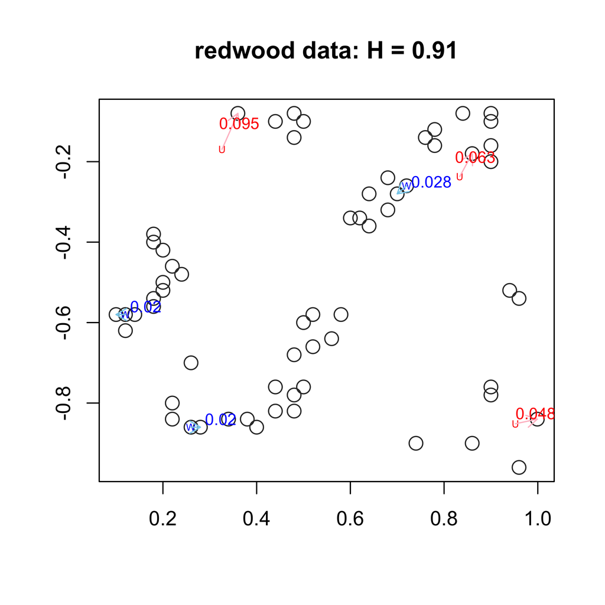

An example of how Hopkins statistic is calculated with clustered data. The black circles are the events of the `redwood` data. Each blue `W` represents a randomly-chosen event. Each blue arrow points from a `W` to the nearest-neighboring event. Each red `U` is a new, randomly-generated point. Each red arrow points from a `U` to the nearest-neighboring event. The numbers are the length of the arrows. In clustered data, red arrows tend to be longer in length than blue arrows.

The `redwood` data are the coordinates of 62 redwood seedlings in a square 23 meters on a side. The plot in Figure @ref(fig:redwood) shows events that exhibit clustering. The value of Hopkins statistic for the plot is:

```r
(.085^2+.078^2+.158^2) /
  ((.085^2+.078^2+.158^2) + (.028^2+.028^2+.12^2))
```

```
## [1] 0.7056101
```

The mean and standard deviation of the 100 Hopkins statistics are 0.78 and 0.14. The value of the statistic is much higher than 0.5, which indicates that the data are somewhat clustered (p-value 0.03).

## Example 4

Adolfsson, Ackerman, and Brownstein (2017) provide a review of various methods of detecting clusterability. One of the methods they considered was Hopkins statistic, which they calculated using 10% sampling. They evaluated the clusterability of nine R datasets by calculating Hopkins statistic 100 times and then reporting the proportion of time that Hopkins statistic exceeded the appropriate beta quantile. We can repeat their analysis and calculate Hopkins statistic for both $d=1$ dimension and $d=D$ dimensions, where $D$ is the number of columns for each dataset.

In this table, `dataset` is the R dataset name, `n` is the number of rows in the data, `D` is the number of columns in the data, `Adolfsson` is the the proportion of 100 times that Hopkins statistic was significant as appearing in the paper by Adolfsson, Ackerman, and Brownsteain (2017), `Hopkins1` is the proportion of 100 times that Hopkins statistic was significant when calculated with the exponent $d=1$ (similar to the `clustertend` package), and `HopkinsD` is the proportion of 100 times that Hopkins statistic was significant when calculated with the exponent $d=D$. Since the `Adolfsson` and `Hopkins1` columns are similar (within samling variation), it appears that Adolfsson, Ackerman, and Brownstein (2017) used the `clustertend` package to calculate Hopkins statistic.

| dataset | n | D | Adolfsson | Hopkins1 | HopkinsD |
| --- | --- | --- | --- | --- | --- |
| faithful | 272 | 2 | 1.00 | 1.00 | 1.00 |
| iris | 150 | 5 | 1.00 | 1.00 | 1.00 |
| rivers | 141 | 1 | 0.92 | 0.90 | 0.92 |
| swiss | 47 | 6 | 0.41 | 0.19 | 0.92 |
| attitude | 30 | 7 | 0.00 | 0.00 | 0.67 |
| cars | 50 | 2 | 0.19 | 0.24 | 0.71 |
| trees | 31 | 3 | 0.18 | 0.20 | 0.70 |
| USJudgeRatings | 43 | 12 | 0.69 | 0.58 | 1.00 |
| USArrests | 50 | 4 | 0.01 | 0.00 | 0.48 |

In Table 1:

- Column 1 is the name of the R dataset.
- Column 2 is the number of observations $n$.
- Column 3 is the number of dimensions $D$.
- Column 4 is the proportion of 100 times that Hopkins statistic is significant as reported by Adolfsson, Ackerman, and Brownstein (2017).
- Columns 5 and 6 use the package. Column 5 is the proportion of 100 times that Hopkins statistic with exponent $d=1$ and column 6 is the proportion of 100 times that Hopkins statistic with exponent $d=D$ is significant.

Since the `Adolfsson` and `Hopkins1` columns are similar (within sampling variability), it appears that Adolfsson, Ackerman, and Brownstein (2017) used Hopkins statistic with $d=1$ as the exponent. This would be expected if they had used the package (YiLan and RuTong 2015 version 1.4) to calculate Hopkins statistic.

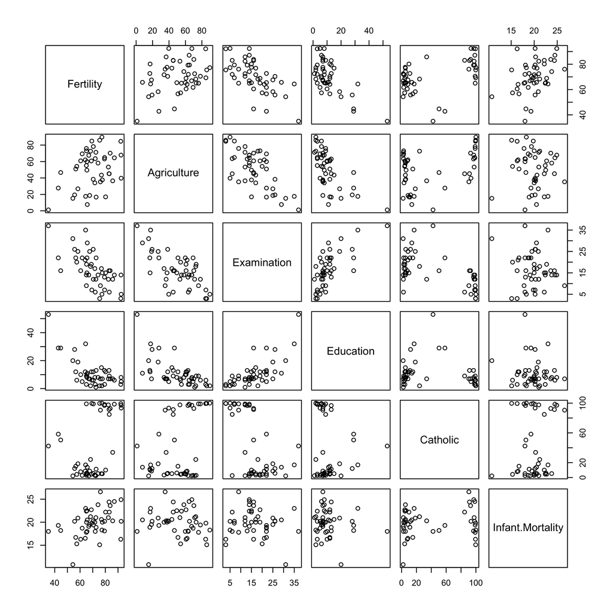

Pairwise scatterplots of the R dataset `swiss`. The meaning of the variables is not important here. Because some panels show a lack of spatial randomness of the data, we would expect Hopkins statistic to be significant.

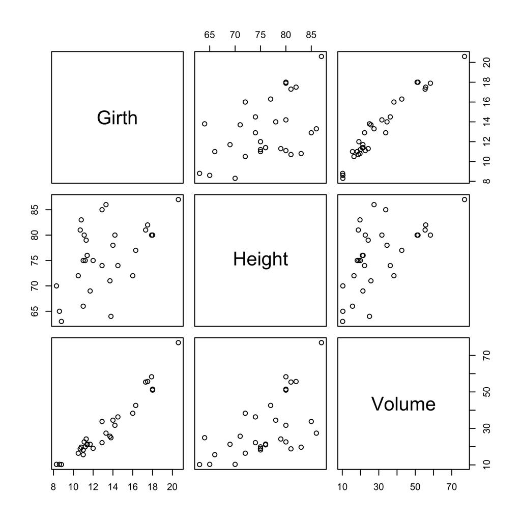

# Correcting for edge effects

To see what effect the torus geometry has on the distribution of the Hopkins statistic, consider the following simulation. We generate $n=100$ events uniformly in a $D=5$ dimension unit cube and sample $m=10$ events to calculate the value of Hopkins statistic using both a simple geometry and a torus geometry. Repeat these steps $B=1000$ times. The calculation of the nearest neighbor using a torus geometry is computationally more demanding than using a simple geometry, especially as the number of dimensions $D$ increases, so the use of parallel computing can reduce the computing time linearly according to the number of processors used. As a point of reference, this small simulation study was performed in less than 1 minute on a reasonably-powerful laptop with 8 cores using the package (Microsoft Corporation and Weston 2020). We found that $B=1000$ provided results that were stable, regardless of the seed value for the random number generation in the simulations.

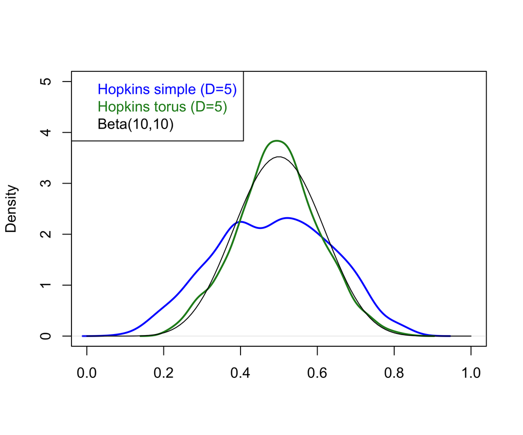

Results of a simulation study considering how the spatial geometry affects Hopkins statistic. The thin black line is the theoretical distribution of Hopkins statistic. The blue and green lines are the empirical density curves of 1000 Hopkins statistics calculated with simple geometry (blue) and torus geometry (green). Calculating Hopkins statistic with a torus geometry aligns closely to the theoretical distribution.

In Figure @ref(fig:torus):

- The black curve is the density of Beta(10,10).
- The blue curve is the empirical density of the 1000 values of Hopkins statistic calculated using a *simple* geometry.
- The green curve is the empirical density of the 1000 values of Hopkins statistic calculated using a *torus* geometry.

When using a torus geometry to correct for edge effects in this example, the empirical distribution of Hopkins statistic is remarkably close to its theoretical distribution. In contrast, when a simple geometry is used, the empirical distribution of Hopkins statistic is somewhat flattened with heavier tails. The practical result is that when no edge correction is used, the Hopkins statistic is more likely to deviate from 0.5 and therefore more likely to suggest the data is not uniformly distributed. This erroneous interpretation is a greater risk as the number of dimensions $D$ increases and edge effects become more pronounced

# Sampling frame effects

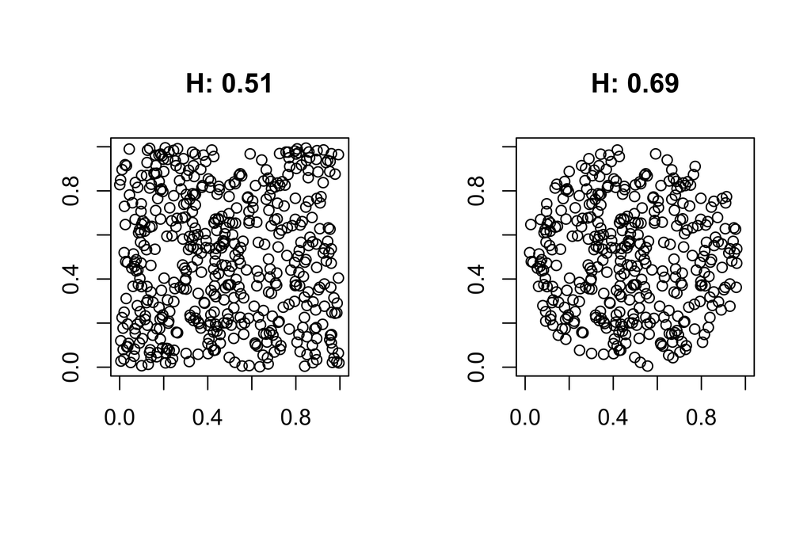

Another practical problem affecting the correct use and interpretation of Hopkins statistic has to do with the shape of the sampling frame. Consider the example data in Figure @ref(fig:frame). On the left side, there were 250 random events simulated in a 2-dimensional unit square. On the right side, the same data are used, but have been subset to keep only the events inside a unit-diameter circle. For both figures, Hopkins statistic was calculated 100 times with 10 events sampled each time.

To consider the problem with the sampling frame on real data, refer again to the `trees` data in Figure @ref(fig:trees). Because trees usually grow both in height and girth at the same time, it would be unexpected to find tall trees with narrow girth or short trees with large girth. Also, since the volume is a function of the girth and height, it is correlated with those two variables. In the scatterplot of girth versus volume, it would be nearly impossible to find points in the upper left or lower right corner of the square. From a biological point of view, the sampling frame cannot be shaped like a square and the null hypothesis of uniform distribution of data is violated *a priori*, which means the distribution of Hopkins statistic does not follow a Beta($m$,$m$) distribution.

# A protocol for using Hopkins statistic

Because Hopkins statistic is not hard to calculate and is easy to interpret, yet can be misused (as shown in the previous sections), we propose a protocol for using Hopkins statistic. The protocol simply asks the practitioner to consider the following five questions before calculating Hopkins statistic.

1. **Is the number of events $\mathbf{n > 100}$ and the number of randomly-sampled events at most 10% of $\mathbf{n}$?** This is recommended by Cross and Jain (1982).
2. **Is spatial randomness of the events even possible?** If the events are known or suspected to be correlated, this violates the null hypothesis of spatial uniformity, and may also mean that the sampling frame is not shaped like a hypercube.
3. **Could nearest-neighbor events have occurred outside the boundary of the sampling frame?** If yes, it may be appropriate to calculate nearest-neighbor distances using a torus geometry.
4. **Is the sampling frame non-rectangular?** If yes, then be extremely careful with the use of Hopkins statistic in how points are samples from $U$.
5. **Is the dimension of the data much greater than 2?** Edge effects are more common in higher dimensions.

The important point of this protocol is to raise awareness of potential problems. We leave it to the practitioner to decide what do with the answers to these questions.

# Conclusion

The statistical literature regarding Hopkins statistic is filled with confusion about how to calculate the statistic. Some publications have erroneously used the exponent $d=1$ in the formula for Hopkins statistic and this error has propagated into much statistical software and led to incorrect conclusions. To remedy this situation, the R package (Wright 2022) provides a function `hopkins()` that calculates Hopkins statistic using the general exponent $d=D$ for D-dimensional data. The function can use simple geometry for fast calculations or torus geometry to correct for edge effects. Using this function, we show that the distribution of Hopkins statistic calculated with the general exponent $d=D$ aligns closely with the theoretical distribution of the statistic. Because inference with Hopkins statistic can be trickier than expected, we introduce a protocol of five questions to consider when using Hopkins statistic.

Alternative versions of Hopkins statistic have been examined by Zeng and Dubes (1985b), Rotondi (1993), Li and Zhang (2007). Other methods of examining multivariate uniformity of data have been considered by Smith and Jain (1984), Yang and Modarres (2017), and Petrie and Willemain (2013).

# Acknowledgements

Thanks to Deanne Wright for bringing the confusion about Hopkins statistic to our attention. Thanks to Vanessa Windhausen and Deanne Wright for reading early drafts of this paper and to Dianne Cook for reviewing the final version. Thanks to Wong (2013) for the package for fast computation of nearest neighbors and thanks to Northrop (2021) for the package for nearest neighbor search on a torus.

Adolfsson, Andreas, Margareta Ackerman, and Naomi C Brownstein. 2017. “To Cluster, or Not to Cluster: How to Answer the Question.” *Proceedings of Knowledge Discovery from Data, Halifax, Nova Scotia, Canada, August 13-17 (TKDD ’17)*. https://maya-ackerman.com/wp-content/uploads/2018/09/clusterability2017.pdf.

Baddeley, Adrian, Rolf Turner, and Ege Rubak. 2021. *spatstat.data: Datasets for ’Spatstat’ Family*. https://CRAN.R-project.org/package=spatstat.data.

Banerjee, Amit, and Rajesh N Dave. 2004. “Validating Clusters Using the Hopkins Statistic.” In *2004 IEEE International Conference on Fuzzy Systems (IEEE Cat. No. 04CH37542)*, 1:149–53. IEEE. https://doi.org/10.1109/FUZZY.2004.1375706.

Brownstein, Naomi C, Andreas Adolfsson, and Margareta Ackerman. 2019. “Descriptive Statistics and Visualization of Data from the R Datasets Package with Implications for Clusterability.” *Data in Brief* 25: 104004. https://doi.org/10.1016/j.dib.2019.104004.

Cross, G R, and A K Jain. 1982. “Measurement of Clustering Tendency.” In *Theory and Application of Digital Control*, 315–20. https://doi.org/10.1016/B978-0-08-027618-2.50054-1.

Diggle, Peter J, Julian Besag, and J Timothy Gleaves. 1976. “Statistical Analysis of Spatial Point Patterns by Means of Distance Methods.” *Biometrics*, 659–67. https://doi.org/10.2307/2529754.

Dubes, Richard C, and Guangzhou Zeng. 1987. “A Test for Spatial Homogeneity in Cluster Analysis.” *Journal of Classification* 4 (1): 33–56. https://doi.org/10.1007/BF01890074.

Gastner, Michael T. 2005. “Spatial Distributions: Density-Equalizing Map Projections, Facility Location, and Two-Dimensional Networks.” PhD thesis, Univ. Michigan. https://hdl.handle.net/2027.42/125368.

Hopkins, Brian, and John Gordon Skellam. 1954. “A New Method for Determining the Type of Distribution of Plant Individuals.” *Annals of Botany* 18 (2): 213–27. https://doi.org/10.1093/oxfordjournals.aob.a083391.

Jurs, Peter C, and Richard G Lawson. 1990. “Clustering Tendency Applied to Chemical Feature Selection.” *Drug Information Journal* 24 (4): 691–704. https://doi.org/10.1177/216847909002400405.

Lawson, Richard G, and Peter C Jurs. 1990. “New Index for Clustering Tendency and Its Application to Chemical Problems.” *Journal of Chemical Information and Computer Sciences* 30 (1): 36–41. https://doi.org/10.1021/ci00065a010.

Li, Fasheng, and Lianjun Zhang. 2007. “Comparison of Point Pattern Analysis Methods for Classifying the Spatial Distributions of Spruce-Fir Stands in the North-East USA.” *Forestry* 80 (3): 337–49. https://doi.org/10.1093/forestry/cpm010.

Microsoft Corporation, and Steve Weston. 2020. *doParallel: Foreach Parallel Adaptor for the ’Parallel’ Package*. https://CRAN.R-project.org/package=doParallel.

Northrop, Paul J. 2021. *donut: Nearest Neighbour Search with Variables on a Torus*. https://CRAN.R-project.org/package=donut.

Petrie, Adam, and Thomas R. Willemain. 2013. “An Empirical Study of Tests for Uniformity in Multidimensional Data.” *Computational Statistics & Data Analysis* 64: 253–68. https://doi.org/10.1016/j.csda.2013.02.013.

Rotondi, Renata. 1993. “Tests of Randomness Based on the k-NN Distances for Data from a Bounded Region.” *Probability in the Engineering and Informational Sciences* 7: 557–69. https://doi.org/10.1017/S0269964800003132.

Smith, Stephen P, and Anil K Jain. 1984. “Testing for Uniformity in Multidimensional Data.” *IEEE Transactions on Pattern Analysis and Machine Intelligence*, no. 1: 73–81. https://doi.org/10.1109/TPAMI.1984.4767477.

Wong, Jeffrey. 2013. *pdist: Partitioned Distance Function*. https://CRAN.R-project.org/package=pdist.

Wright, Kevin. 2022. *hopkins: Calculate Hopkins Statistic for Clustering*. https://CRAN.R-project.org/package=hopkins.

Yang, Mengta, and Reza Modarres. 2017. “Multivariate Tests of Uniformity.” *Statistical Papers* 58: 627–39. https://doi.org/10.1007/s00362-015-0715-x.

YiLan, Luo, and Zeng RuTong. 2015. *clustertend: Check the Clustering Tendency*. https://CRAN.R-project.org/package=clustertend.

Zeng, Guangzhou, and Richard C Dubes. 1985a. “A Comparison of Tests for Randomness.” *Pattern Recognition* 18 (2): 191–98. https://doi.org/10.1016/0031-3203(85)90043-3.

———. 1985b. “A Test for Spatial Randomness Based on k-NN Distances.” *Pattern Recognition Letters* 3 (2): 85–91. https://doi.org/10.1016/0167-8655(85)90013-3.